# Supplementary Analyses: External Source Attribution and Adaptation while Viewing the Hand

Raphael Gastrock

# Overview

This document discusses analyses conducted to support and justify the main tests conducted for the study. These tests are not included in the Results and Discussion sections of the manuscript, but are available for interested readers.

# Setting up the R environment

Our scripts require the use of certain packages. If some packages are not available in your own system, run the command:

> install.packages(c(‘ez’, ‘svglite’, ‘phia’, ‘afex’, ‘lsmeans’, ‘scales’, ‘lsr’, ‘tools’, ‘usdm’, ‘lmtest’, ‘car’, ‘rockchalk’))

We have written code that pre-processes the data, plot figures, and run statistical tests. Import the sources below:

```r
source('R/shared.R')
source('R/learningCurves.R')
source('R/noCursor.R')
source('R/localization.R')
source('R/awareness.R')
source('R/ppdemog.R')
source('R/data.R')
```

Then we need to ensure that the data is available locally. We download the pre-processed data available from OSF. If the files already exist, the output will indicate this.

```r
getPreprocessedData()
```

```
## Making sure pre-processed data is available locally:
## File exists: '30explicit_CI_learningcurves.csv', not downloading.
## File exists: '30explicit_CI_reachaftereffects.csv', not downloading.
## File exists: '30explicit_learningcurves_long.csv', not downloading.
## File exists: '30explicit_learningcurves_wide.csv', not downloading.
## File exists: '30explicit_loc_p3_AOV.csv', not downloading.
## File exists: '30explicit_localization.csv', not downloading.
## File exists: '30explicit_localization_tCI.csv', not downloading.
## File exists: '30explicit_nocursor.csv', not downloading.
## File exists: '30explicit_ppawareness_scores.csv', not downloading.
## File exists: '30explicit_block1_trajectories.csv', not downloading.
## File exists: '30explicit_block2_trajectories.csv', not downloading.
## File exists: '30explicit_block3_trajectories.csv', not downloading.
## File exists: '30implicit_CI_learningcurves.csv', not downloading.
## File exists: '30implicit_CI_reachaftereffects.csv', not downloading.
## File exists: '30implicit_learningcurves_long.csv', not downloading.
## File exists: '30implicit_learningcurves_wide.csv', not downloading.
## File exists: '30implicit_loc_p3_AOV.csv', not downloading.
## File exists: '30implicit_localization.csv', not downloading.
## File exists: '30implicit_localization_tCI.csv', not downloading.
## File exists: '30implicit_nocursor.csv', not downloading.
## File exists: '30implicit_ppawareness_scores.csv', not downloading.
## File exists: '30implicit_block1_trajectories.csv', not downloading.
## File exists: '30implicit_block2_trajectories.csv', not downloading.
## File exists: '30implicit_block3_trajectories.csv', not downloading.
## File exists: 'cursorjump_CI_learningcurves.csv', not downloading.
## File exists: 'cursorjump_CI_reachaftereffects.csv', not downloading.
## File exists: 'cursorjump_learningcurves_long.csv', not downloading.
## File exists: 'cursorjump_learningcurves_wide.csv', not downloading.
## File exists: 'cursorjump_loc_p3_AOV.csv', not downloading.
## File exists: 'cursorjump_localization.csv', not downloading.
## File exists: 'cursorjump_localization_tCI.csv', not downloading.
## File exists: 'cursorjump_nocursor.csv', not downloading.
## File exists: 'cursorjump_ppawareness_scores.csv', not downloading.
## File exists: 'cursorjump_block1_trajectories.csv', not downloading.
## File exists: 'cursorjump_block2_trajectories.csv', not downloading.
## File exists: 'cursorjump_block3_trajectories.csv', not downloading.
## File exists: 'handview_CI_learningcurves.csv', not downloading.
## File exists: 'handview_CI_reachaftereffects.csv', not downloading.
## File exists: 'handview_learningcurves_long.csv', not downloading.
## File exists: 'handview_learningcurves_wide.csv', not downloading.
## File exists: 'handview_loc_p3_AOV.csv', not downloading.
## File exists: 'handview_localization.csv', not downloading.
## File exists: 'handview_localization_tCI.csv', not downloading.
## File exists: 'handview_nocursor.csv', not downloading.
## File exists: 'handview_ppawareness_scores.csv', not downloading.
## File exists: 'handview_block1_trajectories.csv', not downloading.
## File exists: 'handview_block2_trajectories.csv', not downloading.
## File exists: 'handview_block3_trajectories.csv', not downloading.
## File exists: 'participant_demographics.csv', not downloading.
## File exists: 'ppawareness_scores.csv', not downloading.
## File exists: 'aligned_train_deletedtrials.csv', not downloading.
## File exists: 'aligned_nocursor_deletedtrials.csv', not downloading.
## File exists: 'rotated_train_deletedtrials.csv', not downloading.
## File exists: 'rotated_nocursor_deletedtrials.csv', not downloading.
```

Once the data and code are available, we can proceed to the next sections.

## Trial Deletions and Outlier removal

At every section of the experiment where we investigate particular questions (Lerning Rates, Aftereffects, Localization), we had to implement outlier removal procedures which led to the deletion of some trials unusable for further analysis. Here, we layout the total number of trials deletions (and their corresponding percentages) across groups, according to session and task type.

```r
countAllGroupDeletedTrials(session='aligned',task='train')
```

| group | deleted_trials_group | total_trials_group | percent_deleted_group |
| --- | --- | --- | --- |
| 30explicit | 34 | 3019 | 1.12620073 |
| 30implicit | 77 | 2880 | 2.67361111 |
| cursorjump | 117 | 2878 | 4.06532314 |
| handview | 2 | 4176 | 0.04789272 |

```r
countAllGroupDeletedTrials(session='aligned',task='nocursor')
```

| group | deleted_trials_group | total_trials_group | percent_deleted_group |
| --- | --- | --- | --- |
| 30explicit | 2 | 756 | 0.2645503 |
| 30implicit | 12 | 720 | 1.6666667 |
| cursorjump | 16 | 720 | 2.2222222 |
| handview | 9 | 1044 | 0.8620690 |

```r
countAllGroupDeletedTrials(session='rotated',task='train')
```

| group | deleted_trials_group | total_trials_group | percent_deleted_group |
| --- | --- | --- | --- |
| 30explicit | 122 | 8818 | 1.3835337 |
| 30implicit | 79 | 8400 | 0.9404762 |
| cursorjump | 28 | 8400 | 0.3333333 |
| handview | 17 | 12180 | 0.1395731 |

```r
countAllGroupDeletedTrials(session='rotated',task='nocursor')
```

| group | deleted_trials_group | total_trials_group | percent_deleted_group |
| --- | --- | --- | --- |
| 30explicit | 27 | 1512 | 1.7857143 |
| 30implicit | 12 | 1440 | 0.8333333 |
| cursorjump | 56 | 1440 | 3.8888889 |
| handview | 8 | 2088 | 0.3831418 |

For the aligned and rotated cursor and no cursor trials, we see that the percentage of trials deleted are not a cause for concern, but we run a Kruskal-Wallis test to confirm whether group differences exist or not.

```r
getKWTotalDeletions()
```

```
## Aligned Train:
##
##  Kruskal-Wallis rank sum test
##
## data:  deleted_trials by group
## Kruskal-Wallis chi-squared = 19.118, df = 3, p-value = 0.0002585
##
## Aligned No Cursor:
##
##  Kruskal-Wallis rank sum test
##
## data:  deleted_trials by group
## Kruskal-Wallis chi-squared = 3.0453, df = 3, p-value = 0.3847
##
## Rotated Train:
##
##  Kruskal-Wallis rank sum test
##
## data:  deleted_trials by group
## Kruskal-Wallis chi-squared = 5.1921, df = 3, p-value = 0.1583
##
## Rotated No Cursor:
##
##  Kruskal-Wallis rank sum test
##
## data:  deleted_trials by group
## Kruskal-Wallis chi-squared = 6.0301, df = 3, p-value = 0.1102
```

For this test, rejecting the null hypothesis would mean that there are group differences in the percentage of deleted trials. We only observe statistical significance for cursor trials in the aligned session. Nevertheless, this should not affect any further analyses we conduct, as these trials serve merely as baseline measures for each group.

Localization trials become more tricky as there are four groups, with 2 sessions (aligned and rotated), where there will be either active or passive movements within each session. Moreover, the outlier removal procedure we implement here is different, such that hand movements with endpoints beyond ±20° from the arc centre and angular errors beyond ±3 standard deviations from the mean angular error were removed. Thus, a total set of trials will first have responses removed based on the 20-degree criteria. The remaining trials will then have trials removed based on the standard deviation criteria. We tabulate the data below, note that these contain grouped data across all participants, task types, and session.

```r
getTotalGroupDeletedLocTrials()
```

| group | uncleaned_taps | removed_taps | percent_removed | cleaned_taps | deleted_clean | percent_deleted | total_removed | total_percent_deleted |
| --- | --- | --- | --- | --- | --- | --- | --- | --- |
| 30explicit | 5980 | 1939 | 32.42475 | 4041 | 7 | 0.1732244 | 1946 | 32.54181 |
| 30implicit | 5708 | 1541 | 26.99720 | 4167 | 35 | 0.8399328 | 1576 | 27.61037 |
| cursorjump | 5688 | 1390 | 24.43741 | 4298 | 62 | 1.4425314 | 1452 | 25.52743 |
| handview | 8061 | 2310 | 28.65649 | 5751 | 90 | 1.5649452 | 2400 | 29.77298 |

We conduct a Kruskal-Wallis test to confirm whether group differences exist or not.

```r
getKWLocTotalDeletions()
```

```
## All Localization Data:
##
##  Kruskal-Wallis rank sum test
##
## data:  total_removed by group
## Kruskal-Wallis chi-squared = 8.1181, df = 3, p-value = 0.04363
```

The result of the test reaches statistical significance, although marginally. We then investigate whether this difference arises from differences across groups, or whether this is brought about by a difference in the task types (active and passive - for aligned and rotated sessions).

```r
getKWTaskTotalDeletions()
```

```
## All Localization Data:
##
##  Kruskal-Wallis rank sum test
##
## data:  total_removed by task_type
## Kruskal-Wallis chi-squared = 6.4632, df = 3, p-value = 0.09112
```

The lack of statistical significance for this test suggests that differences for the percentage of deleted trials, emanate mostly from differences across groups. However, given that the percentages of deleted trials based on the standard deviation cutoff (as shown above) are not far from each other across groups and are small in magnitude, we are confident that the significance from the initial Kruskal-Wallis test should not affect further analyses we conducted.

## Awareness Scores

### Show scores for all groups

At the end of the experiment, participants had to answer a series of questions to assess their awareness of the perturbation they experienced (adapted from Benson et al., 2011; Modchalingam et al., 2019). Each response was given a score and follow-up questions were dependent on the participant’s responses to the previous question. Scores were added at the end to come up with an Awareness Score for the participant (where, 0 means low awareness and 3 means high awareness). Below are two plots showing the data on awareness scores by group. The barplot shows the number of participants that scored either 0, 1, 2, or 3 on the Awareness Questionnaire, for each of the four groups. The dot plot generated beside it, gives a visual of the number of participants scoring either high or low on the questionnaire, separated according to group.

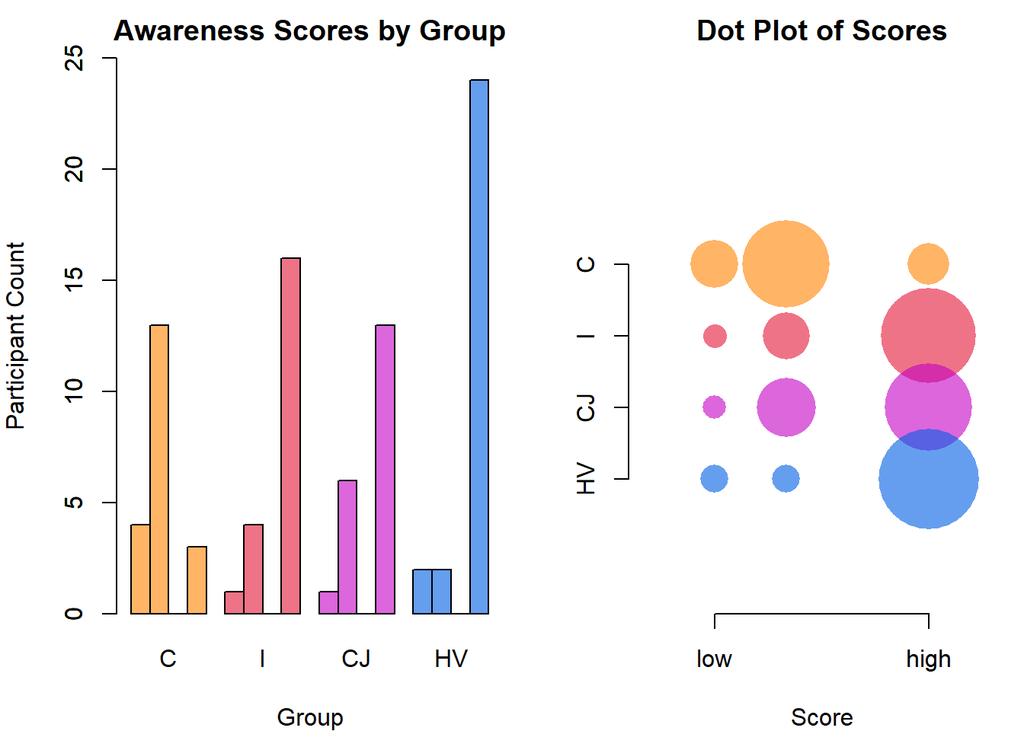

```r
plotAwareness()
```

The plots confirm our findings with the PDP-type analysis. The Control group scored lower on the questionnaire compared to the other groups, suggesting unawareness of the nature of the perturbation.

## Supplementary multiple regression tests conducted

We would want to run the multiple regression again, both when only the Hand View group is considered and when the Hand View group is excluded, to test whether our findings would still hold true.

```r
getHVPropPredGLM()
```

```
##
## Call:
## glm(formula = RAE ~ pred_update + prop_recal)
##
## Deviance Residuals:
##    Min      1Q  Median      3Q     Max
## -6.202  -1.346  -0.279   2.001   4.902
##
## Coefficients:
##             Estimate Std. Error t value Pr(>|t|)
## (Intercept)  1.88583    0.55554   3.395  0.00221 **
## pred_update -0.41859    0.24453  -1.712  0.09883 .
## prop_recal  -0.27678    0.07836  -3.532  0.00156 **
## ---
## Signif. codes:  0 '***' 0.001 '**' 0.01 '*' 0.05 '.' 0.1 ' ' 1
##
## (Dispersion parameter for gaussian family taken to be 7.076675)
##
##     Null deviance: 272.29  on 28  degrees of freedom
## Residual deviance: 183.99  on 26  degrees of freedom
## AIC: 143.88
##
## Number of Fisher Scoring iterations: 2
##
## The deltaR-square values: the change in the R-square
##       observed when a single term is removed.
## Same as the square of the 'semi-partial correlation coefficient'
##             deltaRsquare
## pred_update   0.07615961
## prop_recal    0.32425158
##    Variables      VIF
## 1 prop_recal 1.005451
## 2    include 1.005451
```

When considering only the Hand View group, we find that only changes in proprioceptive estimates are a significant predictor of implicit reach aftereffects. This supports results from our other statistical analyses, as we found that changes in proprioceptive estimates persisted, but efferent-based estimates (updates in predicted sensory consequences) were greatly reduced (not significantly different from zero) for the Hand View group. Effect sizes further show that the percentage of variance in implicit reach aftereffects is attributed more to changes in proprioceptive estimates, rather than updates in prediction.

Next, we conduct the multiple regression without the Hand View group.

```r
getNoHVPropPredGLM()
```

```
##
## Call:
## glm(formula = RAE ~ pred_update + prop_recal)
##
## Deviance Residuals:
##      Min        1Q    Median        3Q       Max
## -10.1331   -3.3499   -0.4618    2.8643   10.1163
##
## Coefficients:
##             Estimate Std. Error t value Pr(>|t|)
## (Intercept)   7.6701     0.9097   8.431 1.17e-11 ***
## pred_update  -0.4133     0.1581  -2.614  0.01139 *
## prop_recal   -0.3451     0.1120  -3.080  0.00316 **
## ---
## Signif. codes:  0 '***' 0.001 '**' 0.01 '*' 0.05 '.' 0.1 ' ' 1
##
## (Dispersion parameter for gaussian family taken to be 17.82532)
##
##     Null deviance: 1256.9  on 60  degrees of freedom
## Residual deviance: 1033.9  on 58  degrees of freedom
## AIC: 353.75
##
## Number of Fisher Scoring iterations: 2
##
## The deltaR-square values: the change in the R-square
##       observed when a single term is removed.
## Same as the square of the 'semi-partial correlation coefficient'
##             deltaRsquare
## pred_update   0.09689331
## prop_recal    0.13455402
##    Variables      VIF
## 1 prop_recal 1.053636
## 2    include 1.053636
```

We find that both changes in proprioceptive estimates and updates in prediction are significant predictors of implicit reach aftereffects. This is expected, as the Instructed, Control, and Cursor Jump groups all showed persistent shifts in both proprioception and predictions.

## Pearson correlation test between implicit reach aftereffects and passive localization

Here, we tested whether the shifts in passive localization are correlated with the angular reach deviations in No Cursor - Without Strategy trials. We performed a Pearson product-moment correlation test, which included all participants regardless of group.

```r
getRAEPropCorrelation()
```

```
##
##  Pearson's product-moment correlation
##
## data:  dat$exclude and dat$prop_recal
## t = -3.4856, df = 88, p-value = 0.000768
## alternative hypothesis: true correlation is not equal to 0
## 95 percent confidence interval:
##  -0.5180279 -0.1521885
## sample estimates:
##        cor
## -0.3483022
```

We found a negative relationship (r = -0.35) between afferent-based changes in localization and reach aftereffects when excluding a strategy (p < 0.001, r-squared = 0.12). This relationship suggests that proprioceptive recalibration could be contributing to the reach aftereffects we have observed.

We performed the same test for updates in predicted sensory consequences and reach aftereffects.

```r
getRAEPredCorrelation()
```

```
##
##  Pearson's product-moment correlation
##
## data:  dat$reachdeviation and dat$pred_update
## t = -2.9334, df = 88, p-value = 0.004274
## alternative hypothesis: true correlation is not equal to 0
## 95 percent confidence interval:
##  -0.47611605 -0.09737975
## sample estimates:
##        cor
## -0.2984521
```

We found a negative realtionship (r = -0.30) between efferent-based changes in localization and reach aftereffects when excluding a strategy (p < 0.01, r-squared = 0.09). This relationship suggests that updates in predictions are also contributing to reach aftereffects.

Performing these two correlations bring about two possible criticisms: 1) Significant relationships found from both correlation tests could be spurious, since data from all individuals across all groups were pooled together. 2) The multiple regression done in the main text will be valid if changes in proprioception are independent from updates in predictions.

## Justification for pooling data across participants from all groups

### 1)

First, we looked into the possibility of a spurious correlation existing within our dataset. Essentially, we are looking for the existence of a group effect. One way of looking into group effects is to see how the relationships of predictions and proprioception with aftereffects change with the removal of the Hand View group (Note that we only remove the Hand View group because it was the group observed to be different from the others in measures of aftereffects and localization). First, we investigate the relationship of predictions and aftereffects, without the Hand View group.

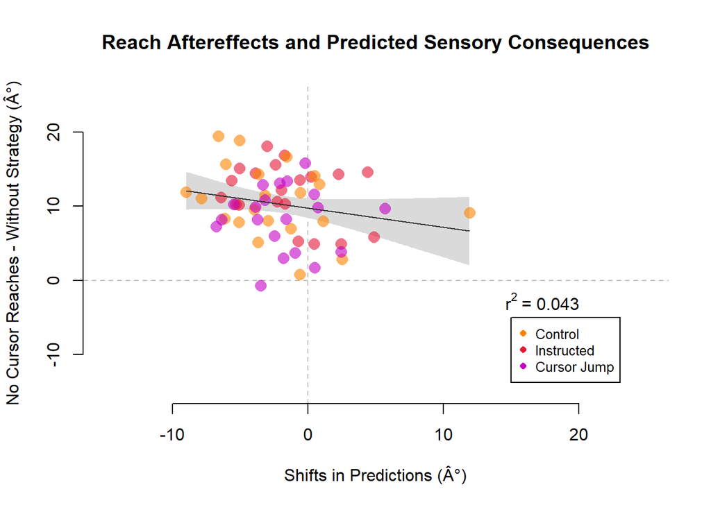

```
##
## Call:
## lm(formula = reachdev ~ pred_update)
##
## Residuals:
##      Min       1Q   Median       3Q      Max
## -11.4243  -3.1410   0.1273   3.5942   7.9257
##
## Coefficients:
##             Estimate Std. Error t value Pr(>|t|)
## (Intercept)   9.7403     0.6557  14.854   <2e-16 ***
## pred_update  -0.2611     0.1606  -1.625    0.109
## ---
## Signif. codes:  0 '***' 0.001 '**' 0.01 '*' 0.05 '.' 0.1 ' ' 1
##
## Residual standard error: 4.515 on 59 degrees of freedom
## Multiple R-squared:  0.04286,    Adjusted R-squared:  0.02664
## F-statistic: 2.642 on 1 and 59 DF,  p-value: 0.1094
```

```r
plotNoHVPredGroupCorrelations()
```

```r
getNoHVRAEPredCorrelation()
```

```
##
##  Pearson's product-moment correlation
##
## data:  dat$reachdeviation and dat$pred_update
## t = -1.6255, df = 59, p-value = 0.1094
## alternative hypothesis: true correlation is not equal to 0
## 95 percent confidence interval:
##  -0.43611858  0.04724889
## sample estimates:
##        cor
## -0.2070352
```

We found that the correlation between predictions and aftereffects, after removing the Hand View group, was not significant (p > 0.10, r = -0.21, r-squared = 0.04). This suggests that the observed effect from previous analyses could be mainly driven by the Hand View group.

Next, we repeat the analyses for proprioceptive recalibration and aftereffects.

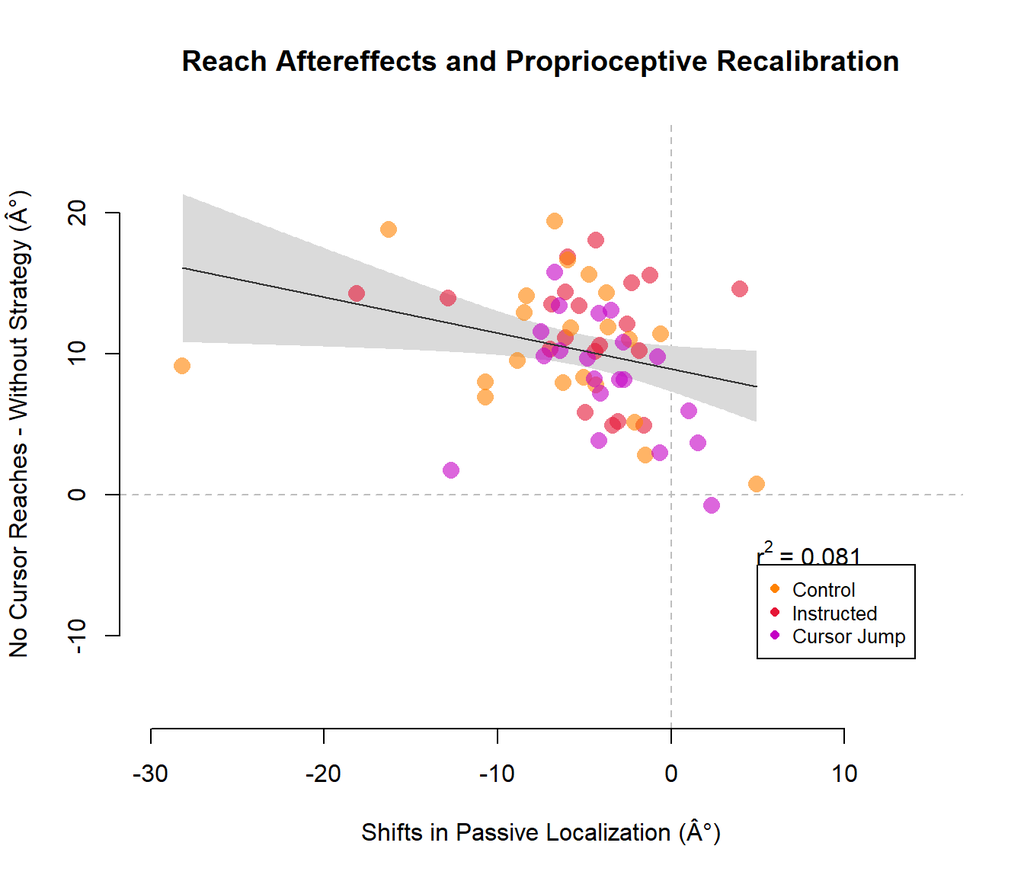

```
##
## Call:
## lm(formula = reachdev ~ prop_recal)
##
## Residuals:
##      Min       1Q   Median       3Q      Max
## -10.4506  -2.7755   0.6379   2.8786   8.7508
##
## Coefficients:
##             Estimate Std. Error t value Pr(>|t|)
## (Intercept)   8.9373     0.8070  11.075 4.88e-16 ***
## prop_recal   -0.2536     0.1116  -2.273   0.0267 *
## ---
## Signif. codes:  0 '***' 0.001 '**' 0.01 '*' 0.05 '.' 0.1 ' ' 1
##
## Residual standard error: 4.426 on 59 degrees of freedom
## Multiple R-squared:  0.08052,    Adjusted R-squared:  0.06494
## F-statistic: 5.167 on 1 and 59 DF,  p-value: 0.02668
```

```r
plotNoHVPropGroupCorrelations()
```

```r
getNoHVRAEPropCorrelation()
```

```
##
##  Pearson's product-moment correlation
##
## data:  dat$exclude and dat$prop_recal
## t = -2.2731, df = 59, p-value = 0.02668
## alternative hypothesis: true correlation is not equal to 0
## 95 percent confidence interval:
##  -0.49986880 -0.03440588
## sample estimates:
##       cor
## -0.283768
```

We found that the correlation between proprioceptive changes and aftereffects, after removing the Hand View group, was significant (p < 0.05, r = -0.28, r-squared = 0.08).

### 2)

We also looked into the relationships of both predictions and proprioception with reach aftereffects, for each individual group. First, I show results for correlation tests between proprioception and aftereffects for each group. I also plot these relationships to visualize the data better.

```r
getPGPropCorr()
```

```
## Hand View group - Propriocetive Recalibration and Reach Aftereffects:
##
##  Pearson's product-moment correlation
##
## data:  dat$reachdeviation and dat$prop_recal
## t = -2.9848, df = 27, p-value = 0.005963
## alternative hypothesis: true correlation is not equal to 0
## 95 percent confidence interval:
##  -0.7311328 -0.1609830
## sample estimates:
##        cor
## -0.4981002
##
## Cursor Jump group - Propriocetive Recalibration and Reach Aftereffects:
##
##  Pearson's product-moment correlation
##
## data:  dat$reachdeviation and dat$prop_recal
## t = -1.5424, df = 18, p-value = 0.1404
## alternative hypothesis: true correlation is not equal to 0
## 95 percent confidence interval:
##  -0.6811933  0.1188212
## sample estimates:
##        cor
## -0.3416646
##
## Instructed group - Propriocetive Recalibration and Reach Aftereffects:
##
##  Pearson's product-moment correlation
##
## data:  dat$reachdeviation and dat$prop_recal
## t = -1.3092, df = 19, p-value = 0.2061
## alternative hypothesis: true correlation is not equal to 0
## 95 percent confidence interval:
##  -0.6398851  0.1644497
## sample estimates:
##        cor
## -0.2876581
##
## Control group - Propriocetive Recalibration and Reach Aftereffects:
##
##  Pearson's product-moment correlation
##
## data:  dat$reachdeviation and dat$prop_recal
## t = -0.73844, df = 18, p-value = 0.4698
## alternative hypothesis: true correlation is not equal to 0
## 95 percent confidence interval:
##  -0.5706910  0.2933019
## sample estimates:
##       cor
## -0.171475
```

```
##
## Call:
## lm(formula = prop_recal ~ reachdev)
##
## Residuals:
##      Min       1Q   Median       3Q      Max
## -17.3669  -0.1675   1.8698   3.3186  10.8137
##
## Coefficients:
##             Estimate Std. Error t value Pr(>|t|)
## (Intercept)  0.03101    1.61941   0.019  0.98486
## reachdev    -1.16763    0.39119  -2.985  0.00596 **
## ---
## Signif. codes:  0 '***' 0.001 '**' 0.01 '*' 0.05 '.' 0.1 ' ' 1
##
## Residual standard error: 6.455 on 27 degrees of freedom
## Multiple R-squared:  0.2481, Adjusted R-squared:  0.2203
## F-statistic: 8.909 on 1 and 27 DF,  p-value: 0.005963
```

```
##
## Call:
## lm(formula = prop_recal ~ reachdev)
##
## Residuals:
##      Min       1Q   Median       3Q      Max
## -10.7058  -1.2632   0.1503   1.7710   4.2216
##
## Coefficients:
##             Estimate Std. Error t value Pr(>|t|)
## (Intercept)  -1.5133     1.6985  -0.891    0.385
## reachdev     -0.2815     0.1825  -1.542    0.140
##
## Residual standard error: 3.44 on 18 degrees of freedom
## Multiple R-squared:  0.1167, Adjusted R-squared:  0.06766
## F-statistic: 2.379 on 1 and 18 DF,  p-value: 0.1404
```

```
##
## Call:
## lm(formula = prop_recal ~ reachdev)
##
## Residuals:
##      Min       1Q   Median       3Q      Max
## -12.7639  -1.2245   0.1907   2.1117   9.4246
##
## Coefficients:
##             Estimate Std. Error t value Pr(>|t|)
## (Intercept)  -2.6318     3.2291  -0.815    0.426
## reachdev     -0.1927     0.2610  -0.738    0.470
##
## Residual standard error: 4.551 on 18 degrees of freedom
## Multiple R-squared:  0.0294, Adjusted R-squared:  -0.02452
## F-statistic: 0.5453 on 1 and 18 DF,  p-value: 0.4698
```

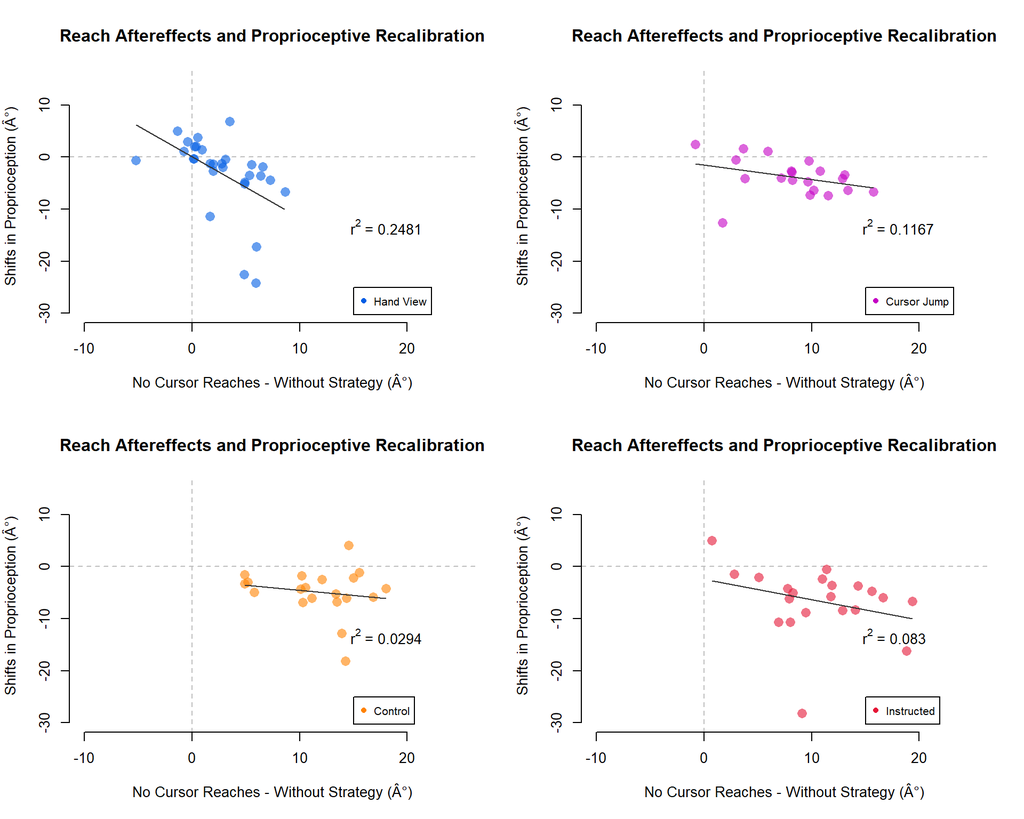

```
##
## Call:
## lm(formula = prop_recal ~ reachdev)
##
## Residuals:
##      Min       1Q   Median       3Q      Max
## -22.1515  -0.9868   1.3045   3.4939   7.7182
##
## Coefficients:
##             Estimate Std. Error t value Pr(>|t|)
## (Intercept)  -2.4760     3.4737  -0.713    0.485
## reachdev     -0.3894     0.2975  -1.309    0.206
##
## Residual standard error: 6.471 on 19 degrees of freedom
## Multiple R-squared:  0.08275,    Adjusted R-squared:  0.03447
## F-statistic: 1.714 on 1 and 19 DF,  p-value: 0.2061
```

```r
plotPGPropCorr()
```

We then repeat the same analyses for predictions and aftereffects.

```r
getPGPredCorr()
```

```
## Hand View group - Predictions and Reach Aftereffects:
##
##  Pearson's product-moment correlation
##
## data:  dat$reachdeviation and dat$pred_update
## t = -0.017867, df = 27, p-value = 0.9859
## alternative hypothesis: true correlation is not equal to 0
## 95 percent confidence interval:
##  -0.3694785  0.3635253
## sample estimates:
##          cor
## -0.003438478
##
## Cursor Jump group - Predictions and Reach Aftereffects:
##
##  Pearson's product-moment correlation
##
## data:  dat$reachdeviation and dat$pred_update
## t = -0.036227, df = 18, p-value = 0.9715
## alternative hypothesis: true correlation is not equal to 0
## 95 percent confidence interval:
##  -0.4493613  0.4356283
## sample estimates:
##          cor
## -0.008538431
##
## Instructed group - Predictions and Reach Aftereffects:
##
##  Pearson's product-moment correlation
##
## data:  dat$reachdeviation and dat$pred_update
## t = -1.383, df = 19, p-value = 0.1827
## alternative hypothesis: true correlation is not equal to 0
## 95 percent confidence interval:
##  -0.6493428  0.1486644
## sample estimates:
##        cor
## -0.3024313
##
## Control group - Predictions and Reach Aftereffects:
##
##  Pearson's product-moment correlation
##
## data:  dat$reachdeviation and dat$pred_update
## t = -1.3424, df = 18, p-value = 0.1961
## alternative hypothesis: true correlation is not equal to 0
## 95 percent confidence interval:
##  -0.6565472  0.1625469
## sample estimates:
##        cor
## -0.3016734
```

```
##
## Call:
## lm(formula = pred_update ~ reachdev)
##
## Residuals:
##     Min      1Q  Median      3Q     Max
## -6.4532 -1.3914 -0.1751  1.1821  4.9556
##
## Coefficients:
##              Estimate Std. Error t value Pr(>|t|)
## (Intercept) -0.008827   0.598486  -0.015    0.988
## reachdev    -0.002583   0.144571  -0.018    0.986
##
## Residual standard error: 2.386 on 27 degrees of freedom
## Multiple R-squared:  1.182e-05,  Adjusted R-squared:  -0.03702
## F-statistic: 0.0003192 on 1 and 27 DF,  p-value: 0.9859
```

```
##
## Call:
## lm(formula = pred_update ~ reachdev)
##
## Residuals:
##     Min      1Q  Median      3Q     Max
## -4.9437 -1.7332 -0.1119  1.8320  7.5661
##
## Coefficients:
##              Estimate Std. Error t value Pr(>|t|)
## (Intercept) -1.786965   1.513885  -1.180    0.253
## reachdev    -0.005893   0.162676  -0.036    0.972
##
## Residual standard error: 3.066 on 18 degrees of freedom
## Multiple R-squared:  7.29e-05,   Adjusted R-squared:  -0.05548
## F-statistic: 0.001312 on 1 and 18 DF,  p-value: 0.9715
```

```
##
## Call:
## lm(formula = pred_update ~ reachdev)
##
## Residuals:
##    Min     1Q Median     3Q    Max
## -4.990 -1.916 -0.110  1.621  6.657
##
## Coefficients:
##             Estimate Std. Error t value Pr(>|t|)
## (Intercept)   1.3618     2.2770   0.598    0.557
## reachdev     -0.2471     0.1840  -1.342    0.196
##
## Residual standard error: 3.209 on 18 degrees of freedom
## Multiple R-squared:  0.09101,    Adjusted R-squared:  0.04051
## F-statistic: 1.802 on 1 and 18 DF,  p-value: 0.1961
```

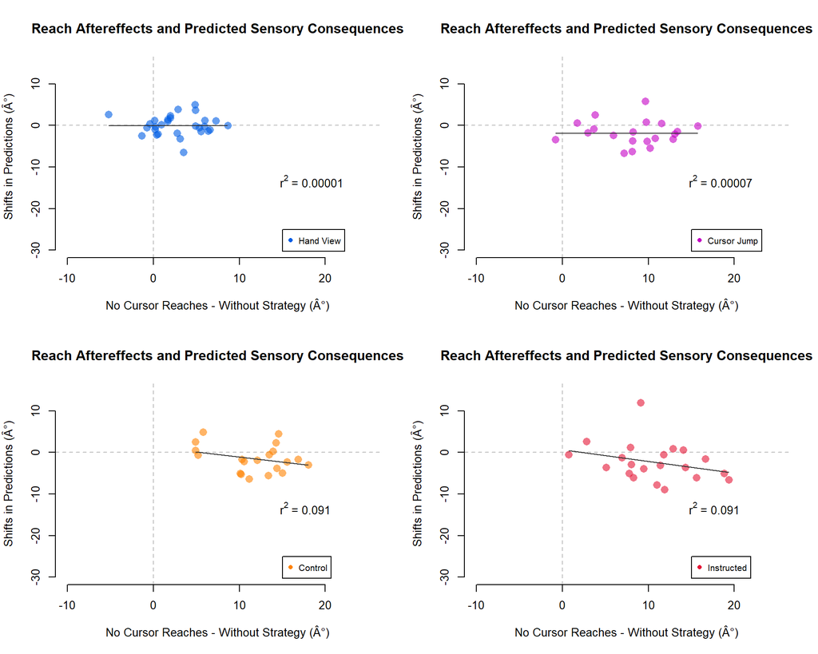

```
##
## Call:
## lm(formula = pred_update ~ reachdev)
##
## Residuals:
##     Min      1Q  Median      3Q     Max
## -6.2501 -2.3003 -0.5786  2.4896 13.8935
##
## Coefficients:
##             Estimate Std. Error t value Pr(>|t|)
## (Intercept)   0.6212     2.3755   0.262    0.797
## reachdev     -0.2813     0.2034  -1.383    0.183
##
## Residual standard error: 4.425 on 19 degrees of freedom
## Multiple R-squared:  0.09146,    Adjusted R-squared:  0.04365
## F-statistic: 1.913 on 1 and 19 DF,  p-value: 0.1827
```

```r
plotPGPredCorr()
```

We see that none of the groups exhibited a significant relationship between predictions and aftereffects (Hand View: p > 0.10, r = -0.003, r-squared = 0.00001; Cursor Jump: p > 0.10, r = -0.009, r-squared = 0.00007; Instructed: p > 0.10, r = -0.30, r-squared = 0.09; Control: p > 0.10, r = -0.30, r-squared = 0.09).

Taken together, these results show that the significant relationship we found, specifically for updates in predictions seem to be spurious. That is, there seems to be a group effect. According to Makin & Orban de Xivry (2019), if a relationship is spurious, then one would need to take into account group differences when pooling data across participants together.

### 3)

To account for group differences, we conducted a mean correction procedure. We took the mean prediction and proprioception values for each group, then subtracted the mean from each individual score within that group. Afterwards, we conducted the multiple regression again on this mean corrected dataset.

```r
getMeanCorrectedGLM()
```

```
##
## Call:
## glm(formula = RAE ~ pas_loc + pred_update, data = data)
##
## Deviance Residuals:
##      Min        1Q    Median        3Q       Max
## -11.1828   -3.8277   -0.3714    4.2415   11.9536
##
## Coefficients:
##             Estimate Std. Error t value Pr(>|t|)
## (Intercept)   7.8396     0.5458  14.362  < 2e-16 ***
## pas_loc      -0.3049     0.1014  -3.007  0.00345 **
## pred_update  -0.4197     0.1811  -2.317  0.02286 *
## ---
## Signif. codes:  0 '***' 0.001 '**' 0.01 '*' 0.05 '.' 0.1 ' ' 1
##
## (Dispersion parameter for gaussian family taken to be 26.81468)
##
##     Null deviance: 2622.9  on 89  degrees of freedom
## Residual deviance: 2332.9  on 87  degrees of freedom
## AIC: 556.36
##
## Number of Fisher Scoring iterations: 2
```

However, we found that both predictors (predictions: p < 0.05; proprioception: p < 0.01) were still significant after doing such a correction.

As a side note, we can also consider proprioception and predictions separately. First, we replot the relationship of proprioceptive recalibration with aftereffects after the correction, then test for a correlation.

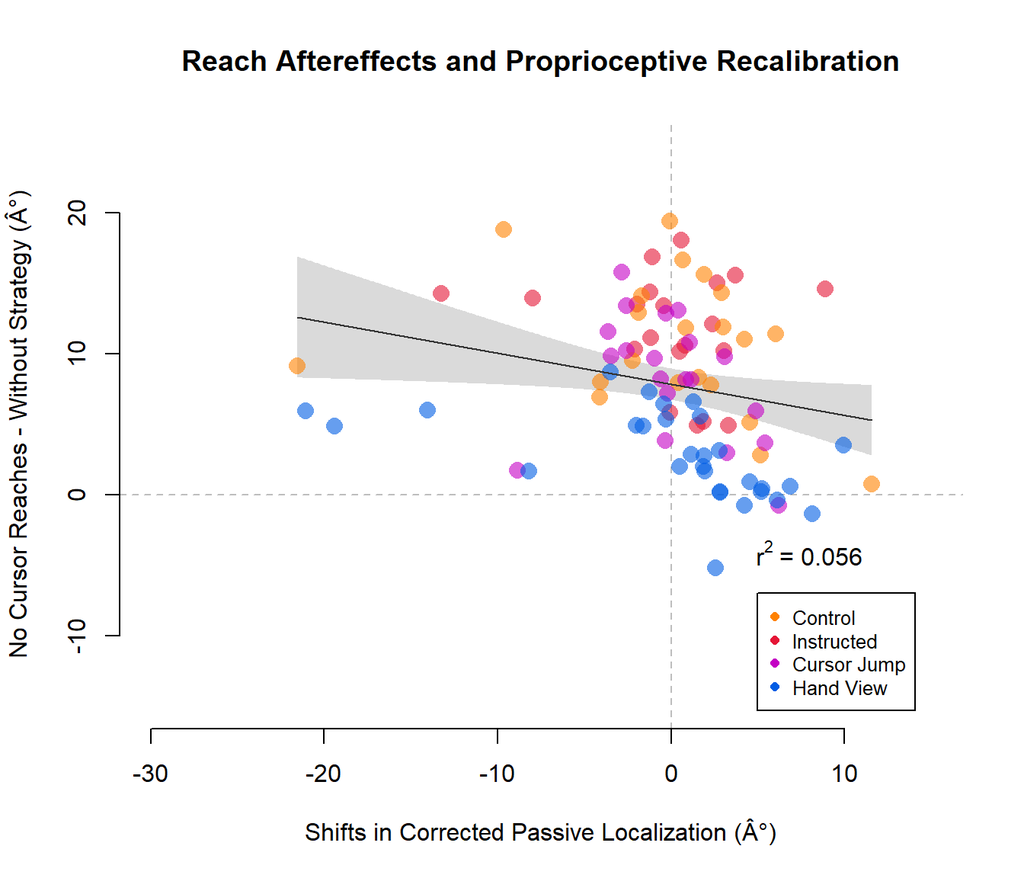

```
##
## Call:
## lm(formula = reachdev ~ prop_recal)
##
## Residuals:
##      Min       1Q   Median       3Q      Max
## -12.4900  -4.1665  -0.3211   4.2778  11.5323
##
## Coefficients:
##             Estimate Std. Error t value Pr(>|t|)
## (Intercept)  7.83956    0.55922  14.019   <2e-16 ***
## prop_recal  -0.22109    0.09704  -2.278   0.0251 *
## ---
## Signif. codes:  0 '***' 0.001 '**' 0.01 '*' 0.05 '.' 0.1 ' ' 1
##
## Residual standard error: 5.305 on 88 degrees of freedom
## Multiple R-squared:  0.0557, Adjusted R-squared:  0.04497
## F-statistic: 5.191 on 1 and 88 DF,  p-value: 0.02513
```

```r
plotMeanCorrectedPropCorrelations()
```

```r
getMeanCorrectedRAEPropCorrelation()
```

```
##
##  Pearson's product-moment correlation
##
## data:  dat$RAE and dat$pas_loc
## t = -2.2783, df = 88, p-value = 0.02513
## alternative hypothesis: true correlation is not equal to 0
## 95 percent confidence interval:
##  -0.42245270 -0.03040403
## sample estimates:
##        cor
## -0.2360091
```

We found that proprioception has a significant relationship with aftereffects (p=0.03, r = -0.24), but this is less in magnitude compared to the original data (r-squared went from 0.12 to 0.06). We repeated the same analyses for predictions.

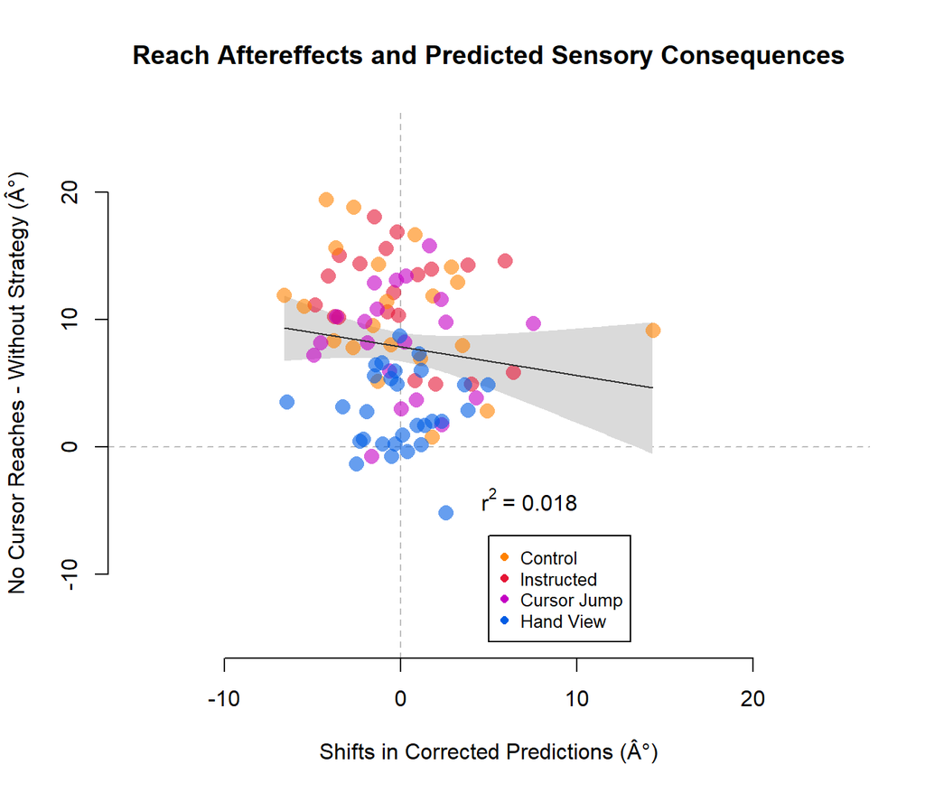

```
##
## Call:
## lm(formula = reachdev ~ pred)
##
## Residuals:
##      Min       1Q   Median       3Q      Max
## -12.4734  -3.9394  -0.3644   4.3454  10.5983
##
## Coefficients:
##             Estimate Std. Error t value Pr(>|t|)
## (Intercept)   7.8396     0.5702  13.748   <2e-16 ***
## pred         -0.2254     0.1768  -1.275    0.206
## ---
## Signif. codes:  0 '***' 0.001 '**' 0.01 '*' 0.05 '.' 0.1 ' ' 1
##
## Residual standard error: 5.41 on 88 degrees of freedom
## Multiple R-squared:  0.01814,    Adjusted R-squared:  0.006978
## F-statistic: 1.625 on 1 and 88 DF,  p-value: 0.2057
```

```r
plotMeanCorrectedPredCorrelations()
```

```r
getMeanCorrectedRAEPredCorrelation()
```

```
##
##  Pearson's product-moment correlation
##
## data:  dat$RAE and dat$pred_update
## t = -1.2749, df = 88, p-value = 0.2057
## alternative hypothesis: true correlation is not equal to 0
## 95 percent confidence interval:
##  -0.3324880  0.0744992
## sample estimates:
##        cor
## -0.1346696
```

We found the predictions did not have a significant relationship with aftereffects (p=0.21, r = -0.13), and r-squared values were reduced from 0.09 to 0.02.

Next, we quantified the difference between this mean corrected model (mod2) from the original model (mod1). From the AIC values, we found that mod1 (AIC = 535.74) seems to be a better model than mod 2 (AIC = 556.36).

Nevertheless, these results show that there is indeed a group effect present (which was expected given the design of the experiment), and this is partially explaining the variance in the data. Despite accounting for groups, we found that both predictors were still significant when we conducted the multiple regression. This suggests that, although a group effect does exist, our conclusion that changes in proprioception and predictions could be contributing to reach aftereffects are justified.

## Independence of changes in proprioception from prediction

Aside from how proprioceptive changes and updates in predictions are calculated. Here, we show semi-partial correlations through regression models, to show the independence of the two.

To show that changes in predictions and proprioception are independent predictors/contributors to reach aftereffects, proprioception should be able to predict the residuals of regressing aftereffects on predictions. That is, the r values here are equivalent to the square root of the squared semi-partial correlations used as effect sizes in the regression we do in our main analyses (see Analyses.Rmd). Hence, the tests here are a more detailed version of the information provided in the main analyses. Note that if we do correlations of the residuals of each predictor with RAE, that would be similar to partial correlations (which is the correlation between one predictor and RAE, after partialling out the effects of both the other predictor and RAE).

```r
getPredResidByPropCorrelation()
```

```
##
##  Pearson's product-moment correlation
##
## data:  mod1_Res and prop
## t = -4.7727, df = 88, p-value = 7.18e-06
## alternative hypothesis: true correlation is not equal to 0
## 95 percent confidence interval:
##  -0.6038417 -0.2718971
## sample estimates:
##        cor
## -0.4534553
```

We find a significant relationship between proprioception and residuals of regressing aftereffects on predictions (p < 0.001, r = -0.45). We can also see if the same is true for predictions and residuals of regressing aftereffects on proprioception.

```r
getPropResidByPredCorrelation()
```

```
##
##  Pearson's product-moment correlation
##
## data:  mod1_Res and pred
## t = -4.3864, df = 88, p-value = 3.185e-05
## alternative hypothesis: true correlation is not equal to 0
## 95 percent confidence interval:
##  -0.5798053 -0.2372980
## sample estimates:
##        cor
## -0.4235737
```

We find a significant relationship as well (p < 0.001, r = -0.42). Lastly, we can compare these two relationships with our original correlational plots.

```
##
## Call:
## lm(formula = reachdev ~ prop_recal)
##
## Residuals:
##      Min       1Q   Median       3Q      Max
## -11.8236  -4.0634  -0.2784   3.7385  10.8567
##
## Coefficients:
##             Estimate Std. Error t value Pr(>|t|)
## (Intercept)  6.39900    0.67956   9.416  5.7e-15 ***
## prop_recal  -0.31817    0.09128  -3.486 0.000768 ***
## ---
## Signif. codes:  0 '***' 0.001 '**' 0.01 '*' 0.05 '.' 0.1 ' ' 1
##
## Residual standard error: 5.118 on 88 degrees of freedom
## Multiple R-squared:  0.1213, Adjusted R-squared:  0.1113
## F-statistic: 12.15 on 1 and 88 DF,  p-value: 0.000768
##
##
## Call:
## glm(formula = mod1_Res ~ pred)
##
## Deviance Residuals:
##     Min       1Q   Median       3Q      Max
## -9.3382  -3.4593  -0.6328   4.0243  13.1090
##
## Coefficients:
##             Estimate Std. Error t value Pr(>|t|)
## (Intercept)  -0.8363     0.5245  -1.594    0.114
## pred         -0.6381     0.1455  -4.386 3.19e-05 ***
## ---
## Signif. codes:  0 '***' 0.001 '**' 0.01 '*' 0.05 '.' 0.1 ' ' 1
##
## (Dispersion parameter for gaussian family taken to be 21.49113)
##
##     Null deviance: 2304.7  on 89  degrees of freedom
## Residual deviance: 1891.2  on 88  degrees of freedom
## AIC: 535.47
##
## Number of Fisher Scoring iterations: 2
```

```
##
## Call:
## lm(formula = reachdev ~ pred_update)
##
## Residuals:
##     Min      1Q  Median      3Q     Max
## -11.191  -3.720  -0.292   4.271   9.495
##
## Coefficients:
##             Estimate Std. Error t value Pr(>|t|)
## (Intercept)   7.2109     0.5896  12.231  < 2e-16 ***
## pred_update  -0.4797     0.1635  -2.933  0.00427 **
## ---
## Signif. codes:  0 '***' 0.001 '**' 0.01 '*' 0.05 '.' 0.1 ' ' 1
##
## Residual standard error: 5.211 on 88 degrees of freedom
## Multiple R-squared:  0.08907,    Adjusted R-squared:  0.07872
## F-statistic: 8.605 on 1 and 88 DF,  p-value: 0.004274
##
##
## Call:
## glm(formula = mod1_Res ~ prop)
##
## Deviance Residuals:
##     Min       1Q   Median       3Q      Max
## -9.6556  -3.1015  -0.3509   3.7624  12.8586
##
## Coefficients:
##             Estimate Std. Error t value Pr(>|t|)
## (Intercept) -1.78999    0.61669  -2.903  0.00468 **
## prop        -0.39535    0.08284  -4.773 7.18e-06 ***
## ---
## Signif. codes:  0 '***' 0.001 '**' 0.01 '*' 0.05 '.' 0.1 ' ' 1
##
## (Dispersion parameter for gaussian family taken to be 21.56813)
##
##     Null deviance: 2389.3  on 89  degrees of freedom
## Residual deviance: 1898.0  on 88  degrees of freedom
## AIC: 535.8
##
## Number of Fisher Scoring iterations: 2
```

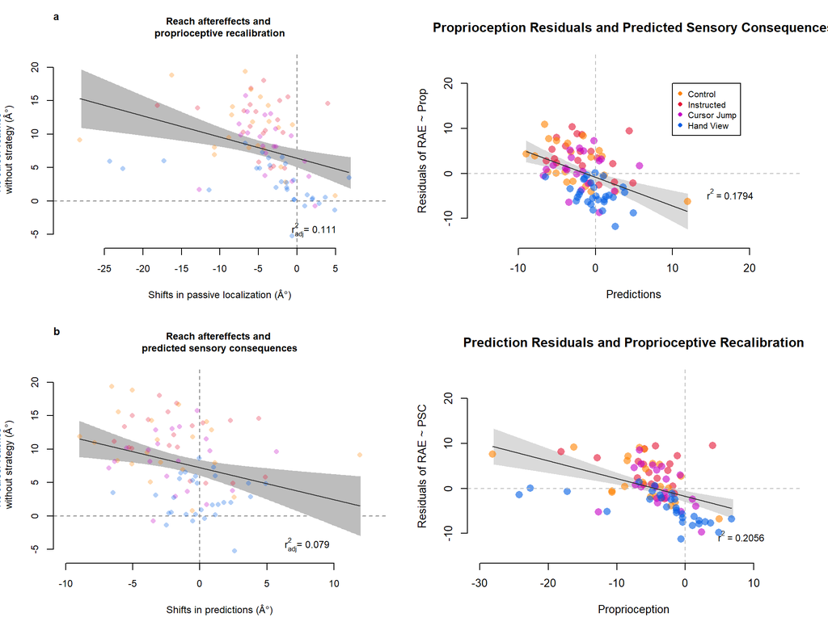

```r
plotRelationships()
```

By considering the residuals, we are essentially controlling for one predictor. However, the existence of a significant relationship, between one predictor and the residuals of aftereffects with the other predictor, suggests that the two predictors are independent from each other.

Next, recall how the VIF score between proprioception and prediction was low. However, the low VIF score from predictions and proprioceptive changes could be trivial, given that predicted sensory consequences are measured by subtracting Passive Localization scores from Active Localization (PSC = ACT - PAS). To investigate this further, we could simulate either ACT or PAS scores that will also have a low VIF score with the other variable, but will not correlate with the residuals of regressing aftereffects on the other variable.

First, we generated simulated PAS scores. To do this, we shuffled the PSC scores then subtracted them from ACT scores. Then we tested whether these simulated PAS scores will correlate with the residuals of regressing reach aftereffects with ACT scores.

```r
getACTResidByFakePASCorrelation()
```

```
##
##  Pearson's product-moment correlation
##
## data:  mod1_Res and PAS
## t = 0.12439, df = 88, p-value = 0.9013
## alternative hypothesis: true correlation is not equal to 0
## 95 percent confidence interval:
##  -0.1943659  0.2197467
## sample estimates:
##        cor
## 0.01325894
##
##   Variables      VIF
## 1  fake_pas 1.107021
## 2       PSQ 1.107021
```

We found that the simulated PAS scores do not significantly correlate with the residuals of regressing aftereffects on ACT, even if ACT was a significant predictor of aftereffects. The VIF score between the simulated PAS scores and PSC was still low. We also repeated this analysis the other way around and generated simulated ACT scores instead.

```r
getPASResidByFakeACTCorrelation()
```

```
##
##  Pearson's product-moment correlation
##
## data:  mod1_Res and ACT
## t = 0.067846, df = 88, p-value = 0.9461
## alternative hypothesis: true correlation is not equal to 0
## 95 percent confidence interval:
##  -0.2001586  0.2140028
## sample estimates:
##         cor
## 0.007232253
##
##   Variables     VIF
## 1  fake_act 1.03941
## 2       PSQ 1.03941
```

We found that the simulated ACT scores do not significantly correlate with the residuals of regressing aftereffects on PAS, even if PAS was a significant predictor of aftereffects. The VIF score between the simulated ACT scores and PSC was still low.

Another simple check is to show that ACT and PAS VIF scores are high, as these are considered to be collinear. This is exactly what we found (vif = 3.37), as shown below.

```r
getActPasCollinearity()
```

```
##   Variables      VIF
## 1   act_loc 3.369193
## 2   pas_loc 3.369193
```

Given the low VIF score we found for predictions and proprioception, but high VIF score for ACT and PAS, we are certain that the VIF score informs uf about the collinearity of these variables. However, it is trivial in its ability to show the independence of predictions from proprioception. Thus, the residual analyses on the previous section above is more informative in showing that these two predictors are independently contributing to reach aftereffects.